# Bengaluru_House_Prediction

## **Import Libraries:**

### **Data Handling**

#### Numpy: Used for numerical operations and handling arrays

#### Pandas: For loading, analyzing, and manipulating tabular data (like .csv files)

### **Data Visualization**

#### matplotlib: To create static plots like bar graphs, line plots, etc

#### Seaborn: A prettier and more powerful layer on top of matplotlib for statistical plots (such as heatmaps, pair plots)

### **Machine Learning**

#### LinearRegression: Used for regression tasks (predicting continuous values)

#### SVC: used for classification tasks (predicting categories)

#### StandardScaler: Scales/normalizes your features so that all have the same scale (very important for SVM)

#### train_test_split: Splits your dataset into training and testing sets

#### accuracy_score, classification_report, confusion_matrix: Used to evaluate how good your model is

### **Saving and Loading Model**

#### pickle: Serializes Saves and load Python objects like your trained model or scaler

```python
import numpy as np  # To perform numerical operations and handling array
import pandas as pd   # Used for For loading, analyzing, and manipulating tabular data
import matplotlib.pyplot as plt  # Used toc create static plots like bar graphs, line plots
import seaborn as sns
# Used for Machine Leaning Processes
from sklearn.linear_model import LinearRegression

from sklearn.svm import SVC
from sklearn.preprocessing import StandardScaler
from sklearn.model_selection import train_test_split
from sklearn.metrics import accuracy_score, classification_report
from sklearn.metrics import accuracy_score, confusion_matrix, classification_report
# For Saving and loading Model
import pickle
```

### **Data Loading**

#### The Data class helps to open a CSV file (like dataset) and handle errors if something goes wrong

```python
# Create Data class to load data
class Data:
    def __init__(self, file_path):
        self.file_path = file_path

    def load_csv(self):
        # Handle errors if something goes wrong
        try:
            self.data = pd.read_csv(self.file_path)
            print("CSV file laoded successfully!")

        except FileNotFoundError:
            print("Error: The file was not found")

        except Exception as e:
            print(f"Error while loading file: {e}")

        return self.data
```

### All Methods with purposes

#### **init**(): Loads the CSV file so you can work with the dataset

#### column_count(): Counts how many columns (features) are in the dataset

#### head() / tail(): Lets peek at the first or last few rows to get an idea of the data

#### shape(): Tells how many rows and columns are in the dataset

#### sample(): Randomly shows a few rows to spot-check the data

#### info(): Gives an overview of each column’s data type and how many missing values

#### describe(): Gives basic statistics like mean, std, min, max for numeric columns

#### loc_rows() / iloc_rows(): Helps retrieve specific rows

#### get_mean() / get_median() / get_mode(): Shows central values for numeric data

#### is_null(): Checks for missing values in the dataset

#### group_by(column): Groups the data by one column and shows the average values per group

```python
class DataProcessor:

    # Loads the CSV file so you can work with the dataset
    def __init__(self, file_path):
        self.data = pd.read_csv(file_path)

    # Counts how many columns (features) are in the dataset
    def column_count(self):
        return self.data.shape[1]

   # Get first 5 rows if no argument is pass
    def head(self, n=5):
        return self.data.head(n)

    # Get last 5 rows if no argument is pass
    def tail(self, n=5):
        return self.data.tail(n)

    # Tells how many rows and columns are in the dataset
    def shape(self):
        return self.data.shape

    # Randomly shows a few rows to spot-check the dat
    def sample(self, n=5):
        return self.data.sample(n)

    # Gives an overview of each column’s data type and how many missing values
    def info(self):
        return self.data.info()

    # Gives basic statistics like mean, std, min, max for numeric columns
    def describe(self):
        return self.data.describe()

    #  Helps retrieve specific row
    def loc_rows(self, start, end):
        return self.data.loc[start:end]

    #  Helps retrieve specific row
    def iloc_rows(self, start, end):
        return self.data.iloc[start:end]

    # Shows central values for numeric data
    def get_mean(self):
        return self.data.mean(numeric_only=True)

    # Shows central values for numeric data
    def get_median(self):
        return self.data.median(numeric_only=True)

    # Shows central values for numeric data
    def get_mode(self):
        return self.data.mode()
    # Checks for missing values in the dataset
    def is_null(self):
        return self.data.isnull().sum()
    # Groups the data by one column and shows the average values per group
    def group_by(self, column_name):
        return self.data.groupby(column_name).mean(numeric_only=True)
```

### **Class Graph Description**

#### Heat_map: Helps detect strong relationships between features for modeling

```python
class Graph:
    def __init__(self, data):
        self.data = data

    # Helps compare average values across categories
    def bar_plot(self, x, y, hue=None):
        plt.figure(figsize=(10, 6))
        sns.barplot(x=x, y=y, hue=hue, data=self.data)
        plt.title(f'Bar Plot: {y} by {x}')
        plt.xticks(rotation=45)
        plt.tight_layout()
        plt.show()

    # Great for seeing frequency of categories
    def count_plot(self, column):
        plt.figure(figsize=(8, 5))
        sns.countplot(x=column, data=self.data)
        plt.title(f'Count Plot of {column}')
        plt.xticks(rotation=45)
        plt.tight_layout()
        plt.show()

    # Shows distribution of numeric data like price or area
    def hist_plot(self, column):
        plt.figure(figsize=(8, 5))
        sns.histplot(self.data[column], kde=True)
        plt.title(f'Histogram of {column}')
        plt.tight_layout()
        plt.show()

    # Detects outliers, medians, and variation in different groups
    def box_plot(self, x, y):
        plt.figure(figsize=(10, 6))
        sns.boxplot(x=x, y=y, data=self.data)
        plt.title(f'Box Plot of {y} by {x}')
        plt.xticks(rotation=45)
        plt.tight_layout()
        plt.show()

    # Detects outliers, medians, and variation in different groups
    def scatter_plot(self, x, y):
        plt.figure(figsize=(8, 5))
        sns.scatterplot(x=x, y=y, data=self.data)
        plt.title(f'Scatter Plot: {y} vs {x}')
        plt.tight_layout()
        plt.show()

    # Helps detect strong relationships between features for modeling
    def heatmap(self):
        plt.figure(figsize=(12, 8))
        sns.heatmap(self.data.corr(numeric_only=True), annot=True, cmap='coolwarm')
        plt.title('Correlation Heatmap')
        plt.tight_layout()
        plt.show()
```

### **Bivariant Analysis:**

#### **init**(self, data): Prepares the tools needed for plotting graphs on your data

#### price_vs_area_type(): Helps to understand how house prices change for built-up, plot, super built-up, etc

#### price_vs_location(): Useful for comparing popular locations and finding the most expensive or affordable ones

#### sqft_vs_price(): Shows the relationship between house size and its price more

#### bhk_vs_price(): Helps check if more bedrooms = higher price, and whether prices are consistent or have outliers

#### show_correlation(): Quickly reveals which features are strongly related

```python
class BivariateAnalysis:
    def __init__(self, data):
        self.data = data
        self.graph = Graph(data)  # Graph class ka object bna liya

    def price_vs_area_type(self):
        print("Box Plot: Price vs Area Type")
        self.graph.box_plot("area_type", "price")

    def price_vs_location(self):
        print("Bar Plot: Avg Price by Location")
        top_locations = self.data['location'].value_counts().head(10).index
        filtered_data = self.data[self.data['location'].isin(top_locations)]
        graph_local = Graph(filtered_data)
        graph_local.bar_plot("location", "price")

    def sqft_vs_price(self):
        print("Scatter Plot: Price vs Total Sqft")
        self.graph.scatter_plot("total_sqft", "price")

    def bhk_vs_price(self):
        print("Box Plot: Price vs BHK")
        if 'bhk' in self.data.columns:
            self.graph.box_plot("bhk", "price")
        else:
            print("Column 'bhk' not found!")

    def show_correlation(self):
        print("Heatmap: Numeric Correlation")
        self.graph.heatmap()
```

### **Univariant Analysis:**

#### **init**(self, data): Prepares the object and the plotting tools to analyze one variable at a time

#### show_price_distribution(): Helps understand if prices are mostly low, high, or spread evenly, useful for spotting trends or outliers

#### show_area_type_distribution(): Useful to see which types of area are most common in the data

#### show_bhk_distribution(): Shows how many houses have 1, 2, 3, or more bedrooms, important for understanding house types

#### show_availability_distribution(): Helps analyze how many houses are ready to move in versus under construction or other statuses

#### show_numeric_descriptions(): Gives a quick statistical overview of numeric features to understand central spread

```python
class UnivariateAnalysis:
    def __init__(self, data):
        self.data = data
        self.graph = Graph(data)  # Reuse the Graph class

    def show_price_distribution(self):
        print("Histogram: Price Distribution")
        self.graph.hist_plot("price")

    def show_area_type_distribution(self):
        print("Count Plot: Area Type")
        self.graph.count_plot("area_type")

    def show_bhk_distribution(self):
        if 'bhk' in self.data.columns:
            print("Count Plot: BHK Distribution")
            self.graph.count_plot("bhk")
        else:
            print("Column 'bhk' not found!")

    def show_availability_distribution(self):
        if 'availability' in self.data.columns:
            print("Count Plot: Availability")
            self.graph.count_plot("availability")
        else:
            print("Column 'availability' not found!")

    def show_numeric_descriptions(self):
        print("Numeric Description:")
        print(self.data.describe())
```

### **Model Class:**

#### scale_data(): Helps the model perform better by normalizing feature ranges (especially for SVM)

#### train_model(): Learns the relationship between features and the target variable

#### predict(): Makes predictions to compare against actual values for evaluation

#### evaluate(): Measures model performance with multiple metrics to understand its strengths and weaknesses

```python
class Model:
    def __init__(self, data, target_column):
        self.data = data
        self.target_column = target_column
        self.model = SVC()
        self.scaler = StandardScaler()

    def split_data(self, test_size=0.2, random_state=42):
        X = self.data.drop(self.target_column, axis=1)
        y = self.data[self.target_column]
        self.X_train, self.X_test, self.y_train, self.y_test = train_test_split(
            X, y, test_size=test_size, random_state=random_state)
        print("Data split done.")

    def scale_data(self):
        self.X_train = self.scaler.fit_transform(self.X_train)
        self.X_test = self.scaler.transform(self.X_test)
        print("Feature scaling complete.")

    def train_model(self):
        self.model.fit(self.X_train, self.y_train)
        print("Model training complete.")

    def predict(self):
        self.y_pred = self.model.predict(self.X_test)
        return self.y_pred

    def evaluate(self):
        print("Accuracy:", accuracy_score(self.y_test, self.y_pred))
        print("\nConfusion Matrix:\n", confusion_matrix(self.y_test, self.y_pred))
        print("\nClassification Report:\n", classification_report(self.y_test, self.y_pred))
```

### **Pickle Class:**

#### **init**(self, model=None): Prepares the class to save or load a model later

#### save_model(filename='svm_model.pkl'): Allows to store the trained model on disk for future use without retraining

#### load_model(filename='svm_model.pkl'): Lets reuse a previously trained model anytime by loading it back

#### predict_new(input_data): Enables making predictions on new, unseen data using the saved model

```python
class PickleData:
    def __init__(self, model=None):
        self.model = model

    def save_model(self, filename='svm_model.pkl'):
        with open(filename, 'wb') as file:
            pickle.dump(self.model, file)
        print(f"Model saved as {filename}")

    def load_model(self, filename='svm_model.pkl'):
        with open(filename, 'rb') as file:
            self.model = pickle.load(file)
        print(f"Model loaded from {filename}")

    def predict_new(self, input_data):
        if self.model is None:
            print("Model is not loaded!")
            return None
        input_array = np.array(input_data).reshape(1, -1)
        prediction = self.model.predict(input_array)
        print("Prediction:", prediction)
        return prediction
```

### **Data Loading**

```python
loader =  Data("Bengaluru_House_Data.csv") # Load the data of Bengaluru House
df = loader.load_csv()
```

```
CSV file laoded successfully!
```

### **Data Preprocessing**

```python
processor = DataProcessor("Bengaluru_House_Data.csv")
print(processor.head()) # To show Head(First 5 Column
print(processor.describe())
print(processor.is_null()) # To find null values are exist or not
print(processor.group_by("area_type"))
```

```
              area_type   availability                  location       size  \
0  Super built-up  Area         19-Dec  Electronic City Phase II      2 BHK
1            Plot  Area  Ready To Move          Chikka Tirupathi  4 Bedroom
2        Built-up  Area  Ready To Move               Uttarahalli      3 BHK
3  Super built-up  Area  Ready To Move        Lingadheeranahalli      3 BHK
4  Super built-up  Area  Ready To Move                  Kothanur      2 BHK

   society total_sqft  bath  balcony   price
0  Coomee        1056   2.0      1.0   39.07
1  Theanmp       2600   5.0      3.0  120.00
2      NaN       1440   2.0      3.0   62.00
3  Soiewre       1521   3.0      1.0   95.00
4      NaN       1200   2.0      1.0   51.00
               bath       balcony         price
count  13247.000000  12711.000000  13320.000000
mean       2.692610      1.584376    112.565627
std        1.341458      0.817263    148.971674
min        1.000000      0.000000      8.000000
25%        2.000000      1.000000     50.000000
50%        2.000000      2.000000     72.000000
75%        3.000000      2.000000    120.000000
max       40.000000      3.000000   3600.000000
area_type          0
availability       0
location           1
size              16
society         5502
total_sqft         0
bath              73
balcony          609
price              0
dtype: int64
                          bath   balcony       price
area_type
Built-up  Area        2.649378  1.472727  104.285498
Carpet  Area          2.505747  1.402439   89.502356
Plot  Area            3.893479  1.392488  208.495486
Super built-up  Area  2.430386  1.658100   92.971757
```

### **Implement Graphs**

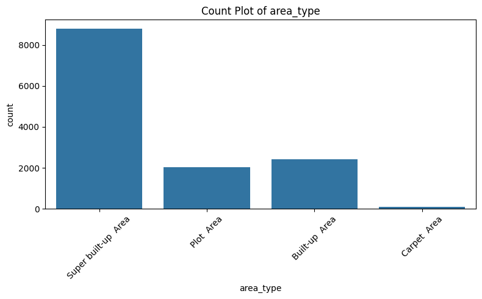

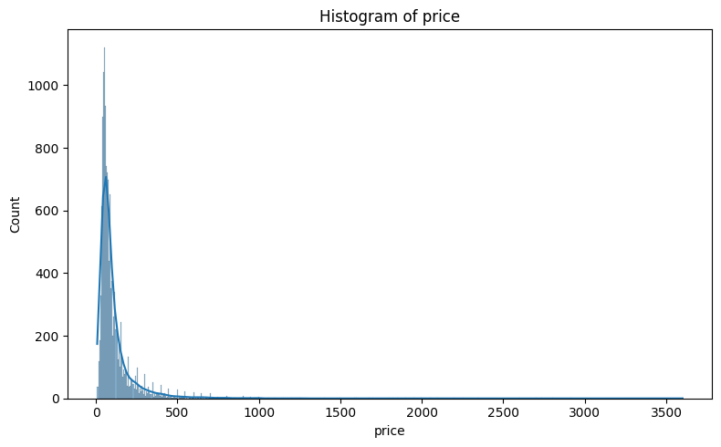

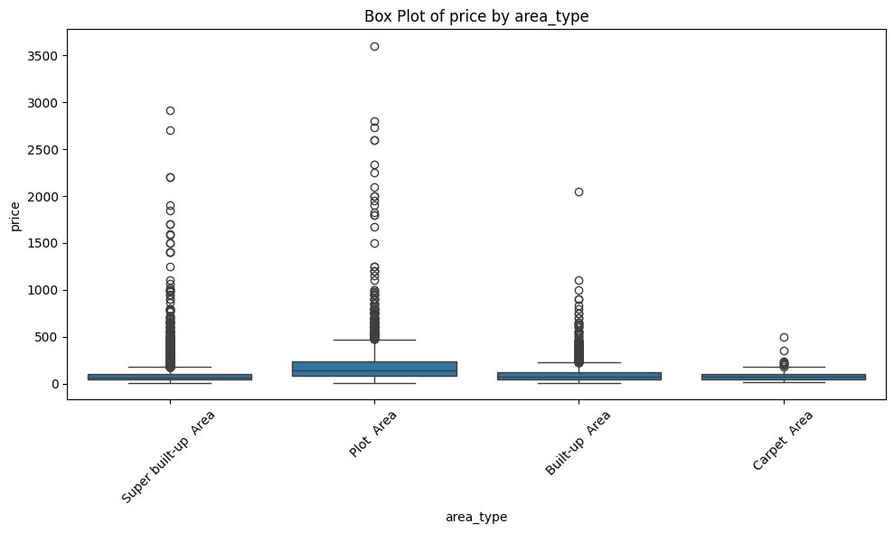

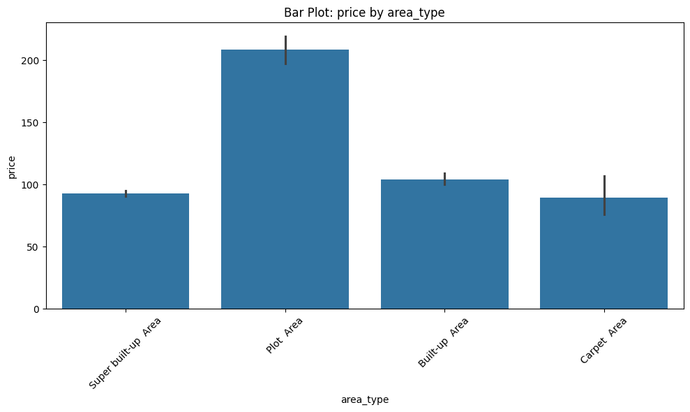

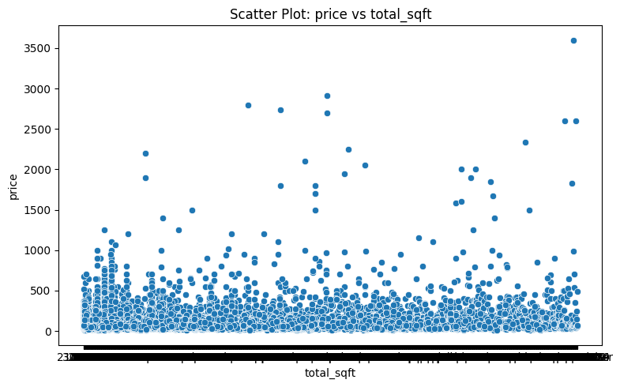

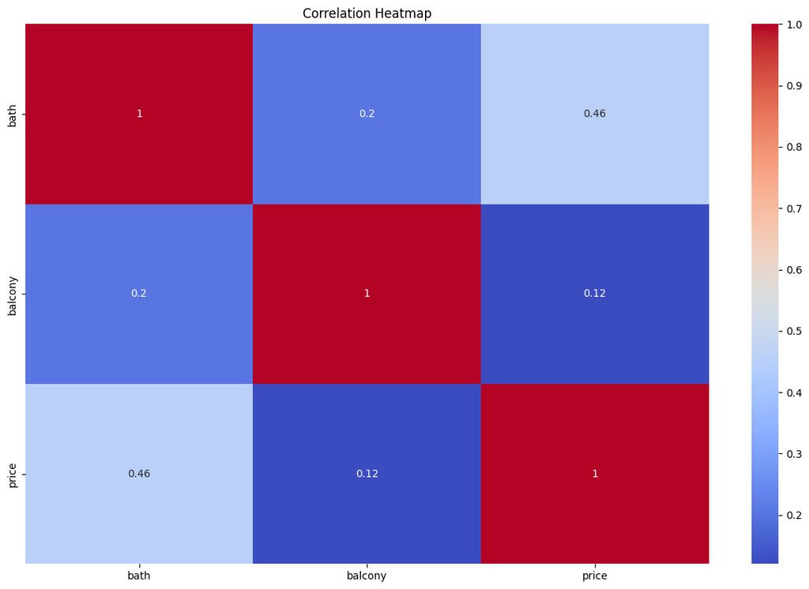

```python
graph = Graph(processor.data)  # Objects of Graph Class

# Implement Count Plot
graph.count_plot("area_type")

# Implement Histogram
graph.hist_plot("price")

# Implement Box Plot
graph.box_plot("area_type", "price")

# Implement Bar Plot
graph.bar_plot("area_type", "price")

# Implement Scatter Plot
graph.scatter_plot("total_sqft", "price")

# Implement Heatmap
graph.heatmap()
```

### **Bivariant Analysis**

```
Box Plot: Price vs Area Type
```

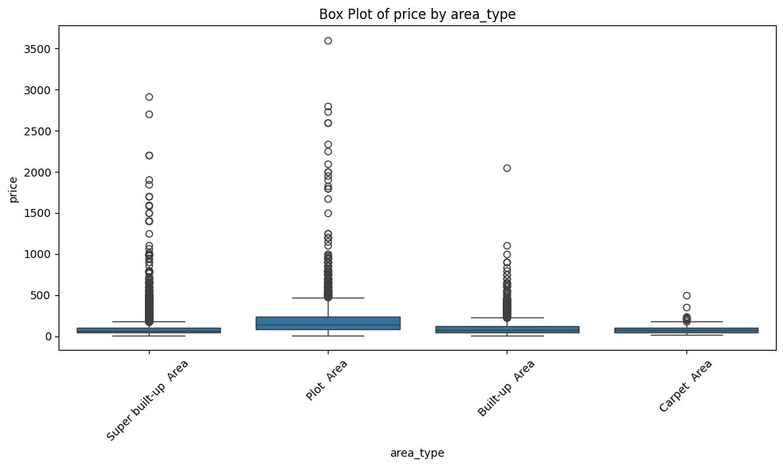

```
Bar Plot: Avg Price by Location
```

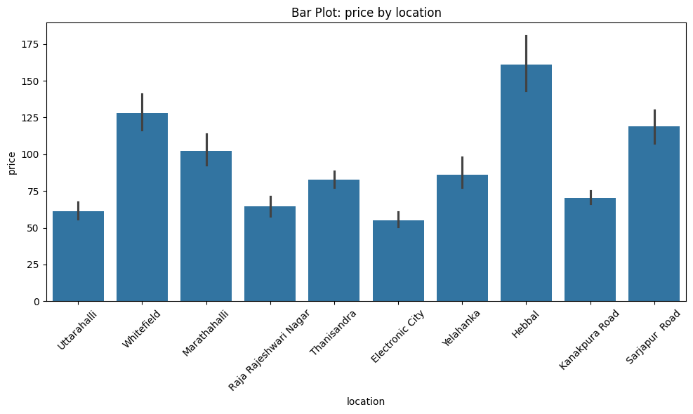

```
Scatter Plot: Price vs Total Sqft
```

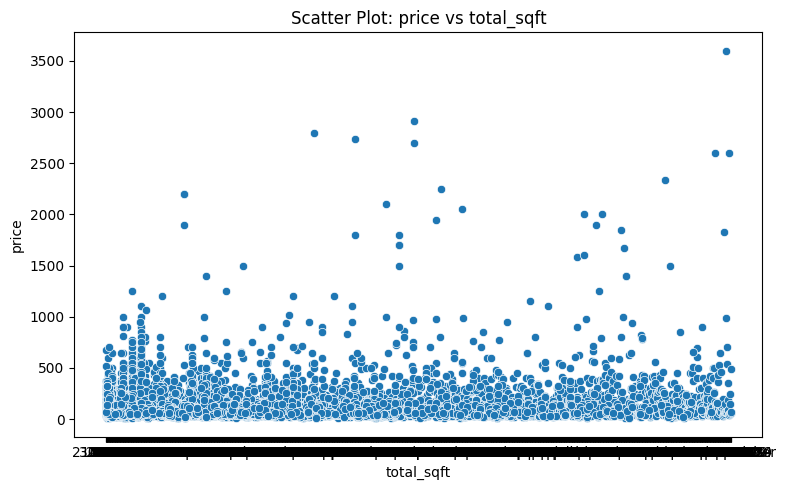

```
Box Plot: Price vs BHK
Column 'bhk' not found!
Heatmap: Numeric Correlation
```

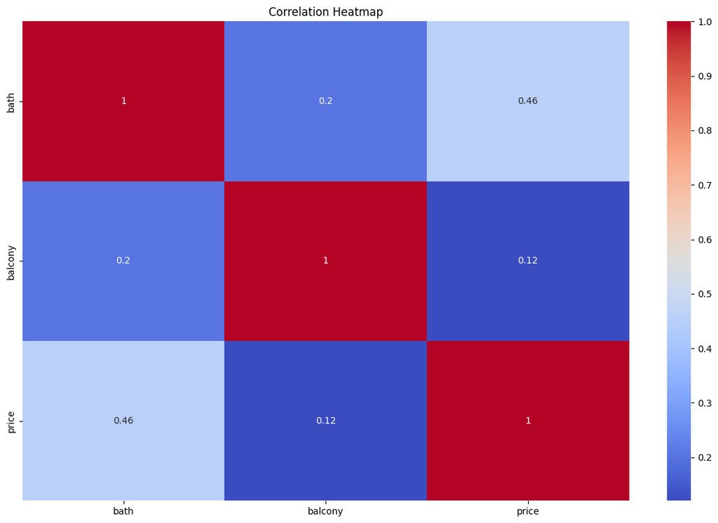

```python
bivar = BivariateAnalysis(processor.data)  # Pass the actual DataFrame

bivar.price_vs_area_type()
bivar.price_vs_location()
bivar.sqft_vs_price()
bivar.bhk_vs_price()
bivar.show_correlation()
```

### **Univariant Analysis**

```
Histogram: Price Distribution
```

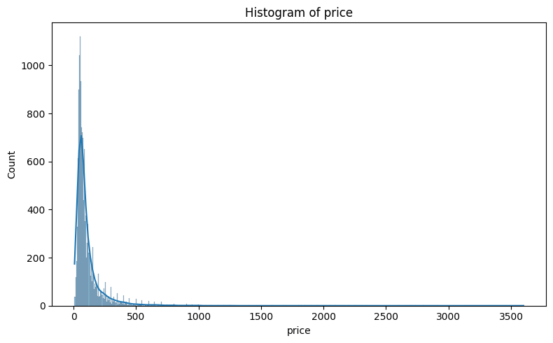

```
Count Plot: Area Type
```

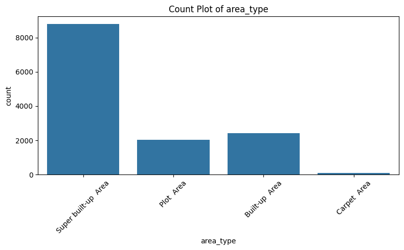

```
Column 'bhk' not found!
Count Plot: Availability
```

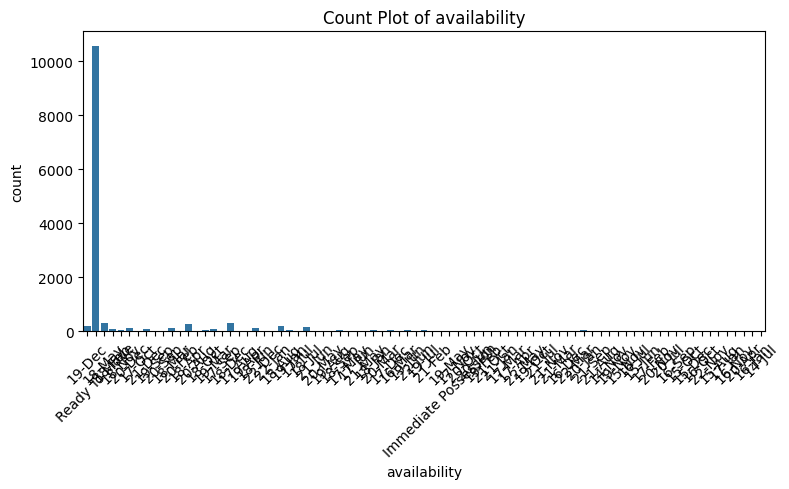

```
Numeric Description:
               bath       balcony         price
count  13247.000000  12711.000000  13320.000000
mean       2.692610      1.584376    112.565627
std        1.341458      0.817263    148.971674
min        1.000000      0.000000      8.000000
25%        2.000000      1.000000     50.000000
50%        2.000000      2.000000     72.000000
75%        3.000000      2.000000    120.000000
max       40.000000      3.000000   3600.000000
```

```python
uni = UnivariateAnalysis(processor.data)

uni.show_price_distribution()
uni.show_area_type_distribution()
uni.show_bhk_distribution()
uni.show_availability_distribution()
uni.show_numeric_descriptions()
```

### **Train Model**

```python
# Load and preprocess data
processor = DataProcessor("Bengaluru_House_Data.csv")
data = processor.data.copy()

# Create the price_category column
bins = [0, 50, 100, 500]
labels = ['Low', 'Medium', 'High']
data['price_category'] = pd.cut(data['price'], bins=bins, labels=labels)

# Drop rows where target or any feature is missing (Na)
data = data.dropna()  # Drop rows with NaNs in any column

# Keep numeric columns only for features plus target
X_numeric = data.select_dtypes(include=['number']).copy()
X_numeric['price_category'] = data['price_category']

model = Model(X_numeric, target_column='price_category')

model.split_data()
model.scale_data()
model.train_model()
model.predict()
model.evaluate()
```

```
Data split done.
Feature scaling complete.
Model training complete.
Accuracy: 0.9838274932614556

Confusion Matrix:
 [[373   0   7]
 [  0 404  10]
 [  2   5 683]]

Classification Report:
               precision    recall  f1-score   support

        High       0.99      0.98      0.99       380
         Low       0.99      0.98      0.98       414
      Medium       0.98      0.99      0.98       690

    accuracy                           0.98      1484
   macro avg       0.99      0.98      0.98      1484
weighted avg       0.98      0.98      0.98      1484
```

### **Pickle Data**

```python
# Save trained model
pickle_util = PickleData(model=model.model)
pickle_util.save_model()

# load model and predict
pickle_util.load_model()
input_features = [1200, 2, 1]  # exactly 3 features
pickle_util.predict_new(input_features)
```

```
Model saved as svm_model.pkl
Model loaded from svm_model.pkl
Prediction: ['High']
```

```
array(['High'], dtype=object)
```